# Transposable elements (TE) analysis in public datasets spanning pre- and postimplantation mouse development

Sara Formichetti

EMBL Rome  
sara.formichetti@embl.it

April 11th, 2023

# 1 Mapping and TE counts stats

Note that:

- STAR parameters were adjusted for trasposable elements analysis (and can be found in embryo_public_data_GSE66582_GSE76505_reanalysis/snake-make/TE_RNASeq_w_Clontech_trim.Snakefile)
- featureCounts was run using RepeatMasker annotation and for both all TE and only full-length (fl) ones

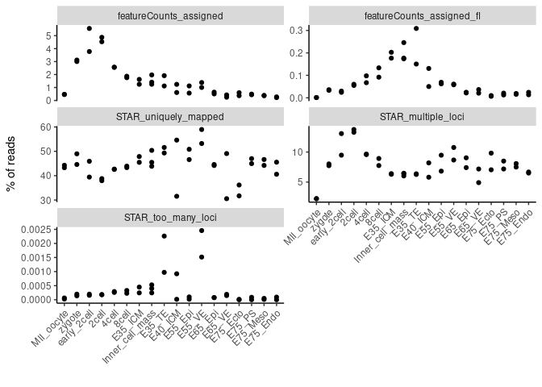

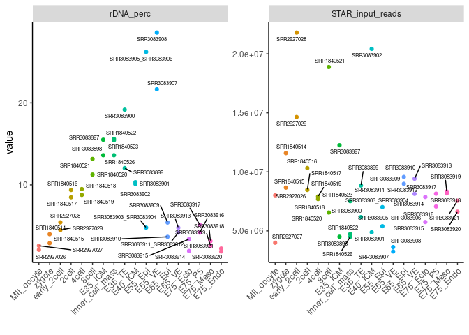

# 2 Reading TE counts

The input files are:

- the output tables made by featureCounts (run in rule ‘count_on_TE’ of the Snakefile), which contain read counts of all repetitive elements (i.e. all repNames) for all samples
- the repetitive elements annotation ../../data/annotations/RepeatMasker_RepeatLibrary20140131_mm10.noGenes.noSimple.bed (converted to SAF format in rule of Snakefile) used for featureCounts command, that is used to retrieve repFamily and repClass for each repName. The annotation I chose is the most updated library to Nov2020 of rmsk, from which I removed ‘Simple repeats’ and ‘Low complexity regions’
- a table with total number of reads per sample in raw fastq files
- the samples’ table, containing metadata (i.e. stage)

# 3 Analysis at family level

## 3.1 FPKM for each family of Repetitive Elements

For each family of Repetitive Elements (in case of elements with no repFamily name or repFamilies belonging to more than one repClass I use repClass) I compute **FPKM** values, as follows: for each sample:

- I compute the sum of counts for all elements belonging to that repFamily
- I divide this sum by the total number of reads sequenced for that sample and multiply by 10⁶
- I divide this number by the total sum of lengths (in Kb) of the elements belonging to that repFamily –> FPKM
- When specified, **I subtract from each FPKM the total FPKM of all transposons belonging to the DNA repClass**

## 3.2 Heatmaps

The heatmaps are scaled by rows.

### 3.2.1 Preimplantation stages only

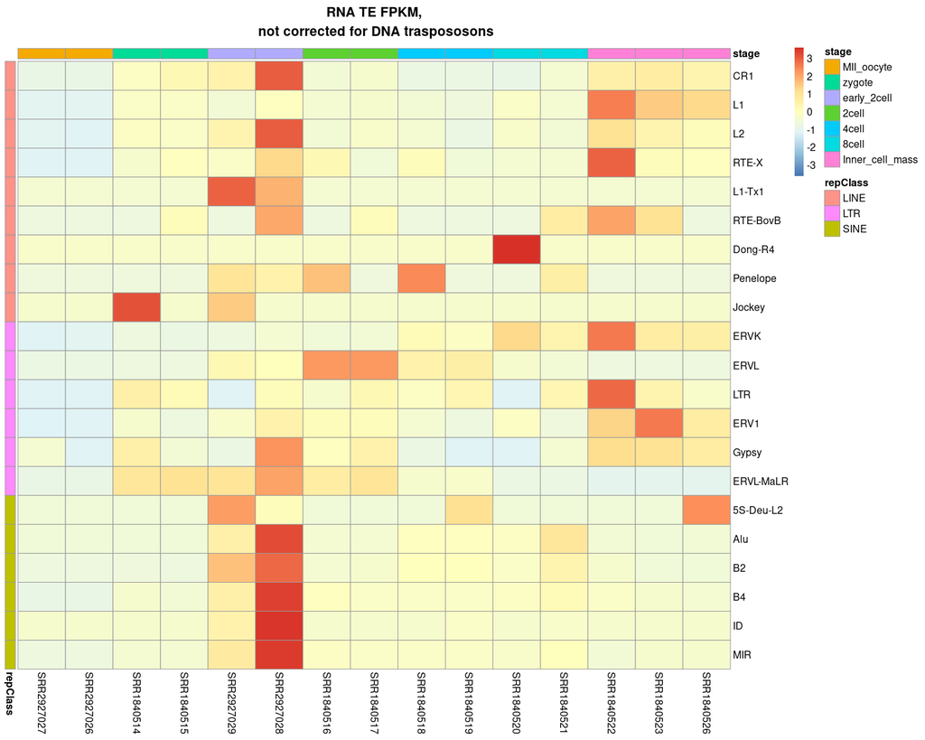

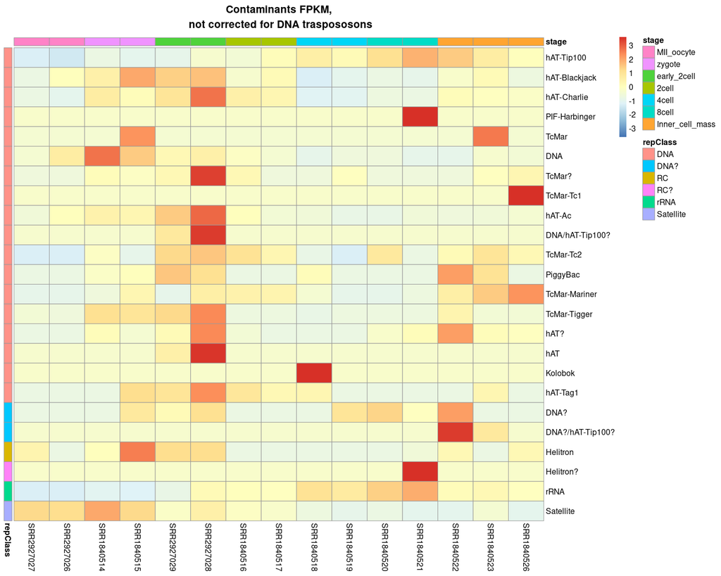

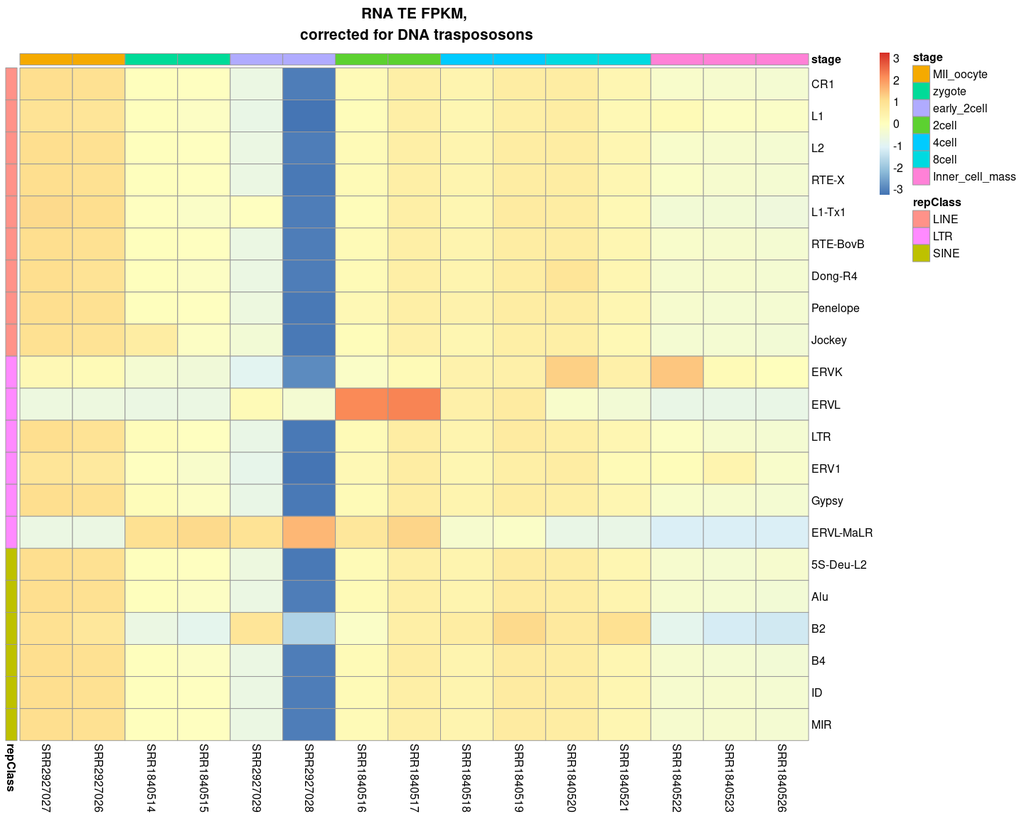

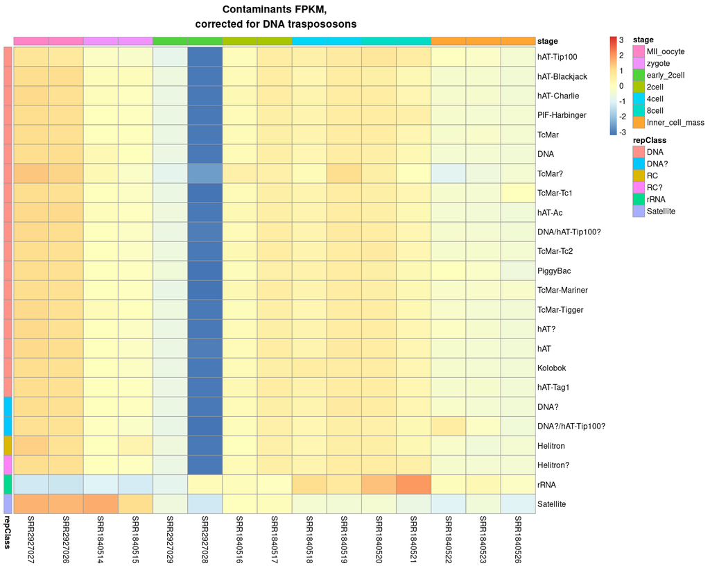

### 3.2.2 Postimplantation stages only

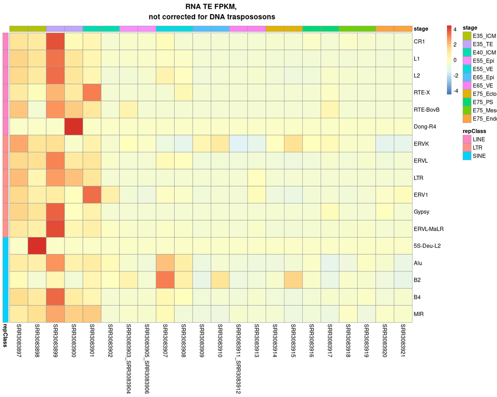

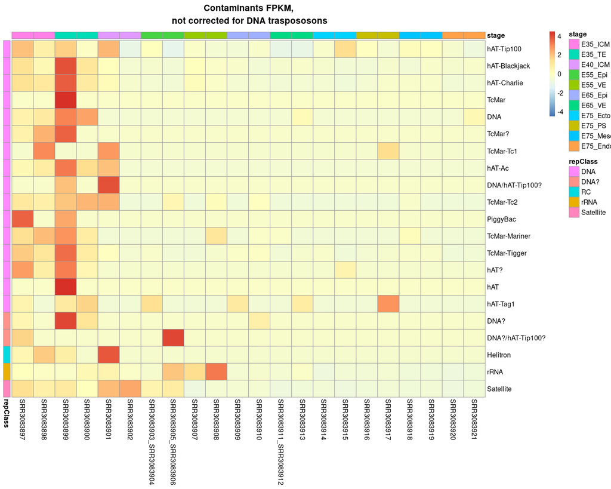

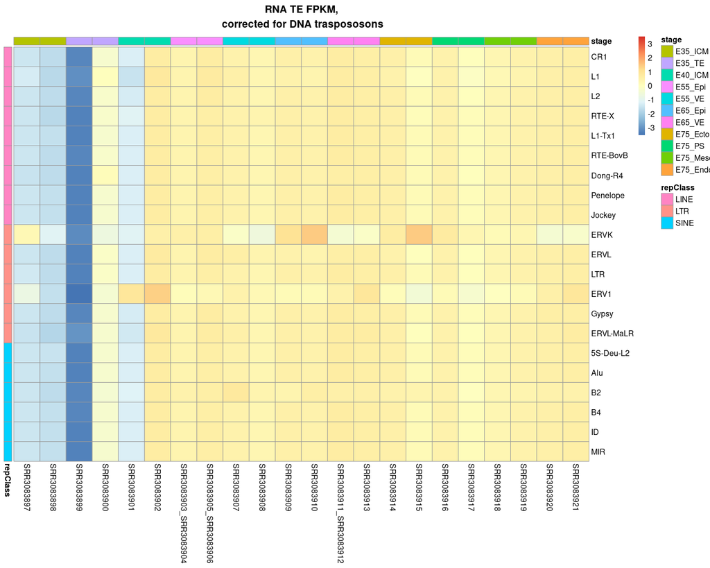

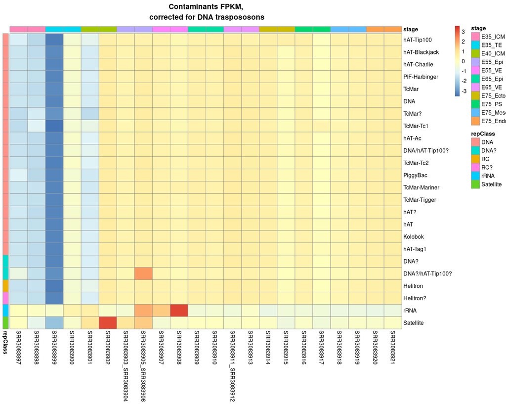

### 3.2.3 All stages

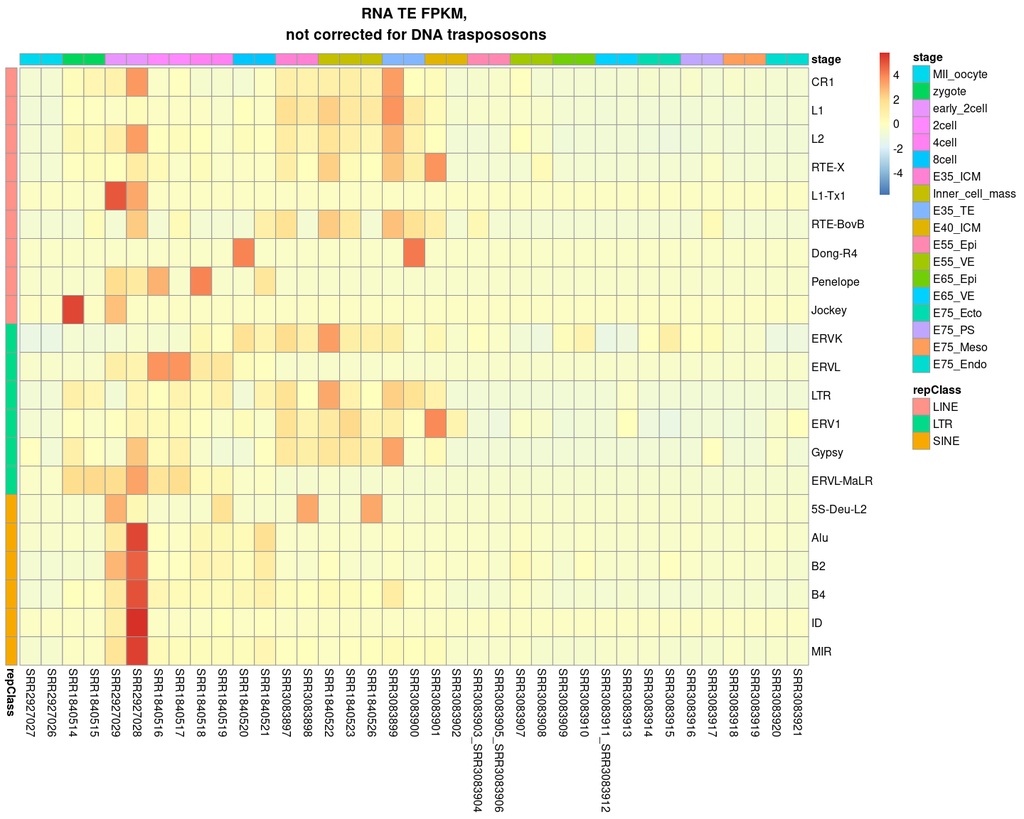

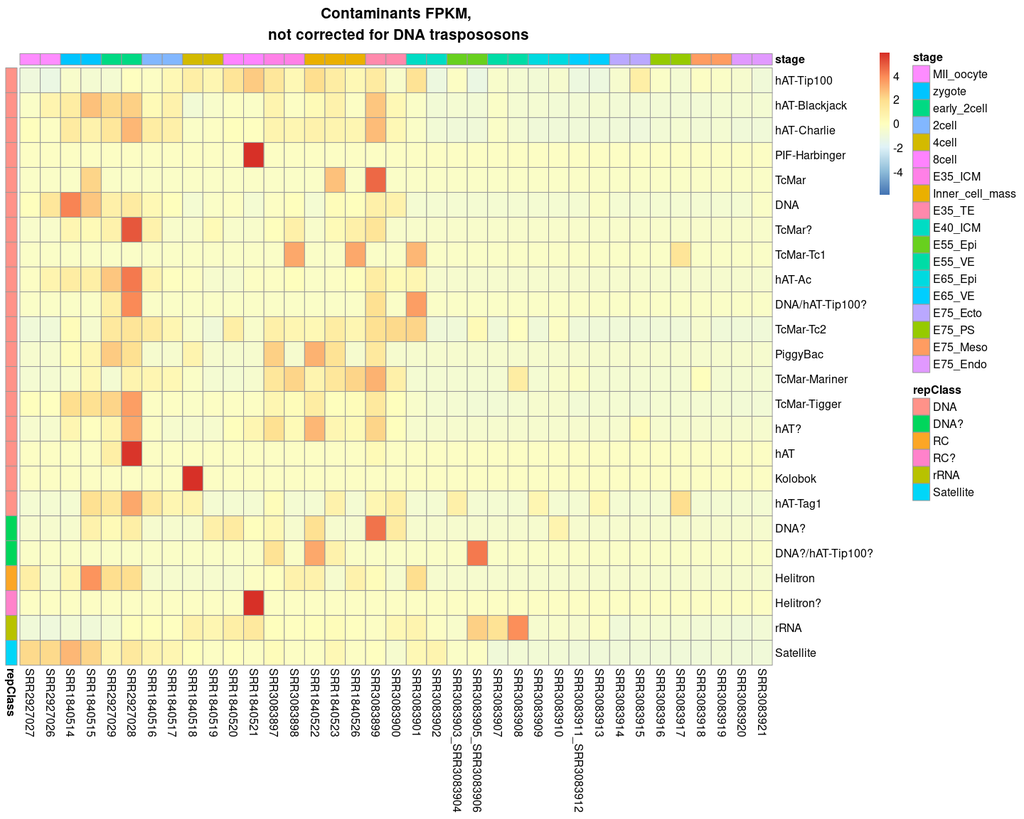

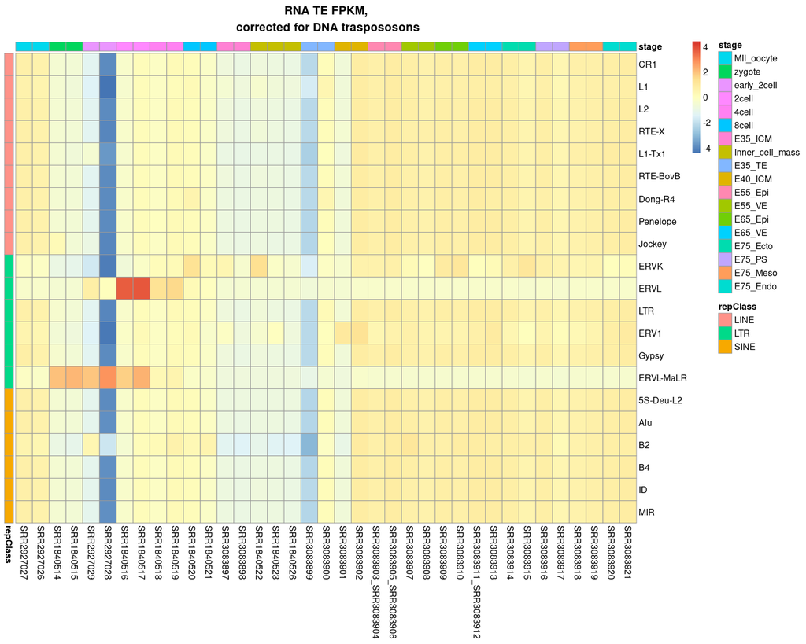

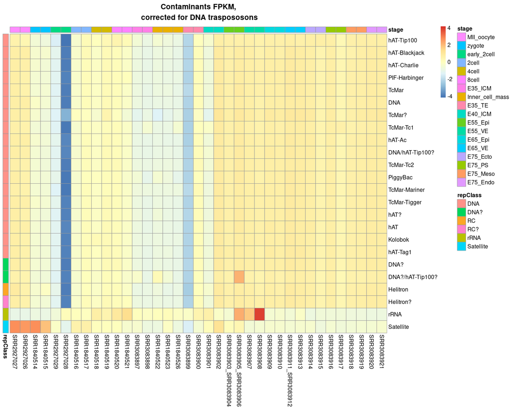

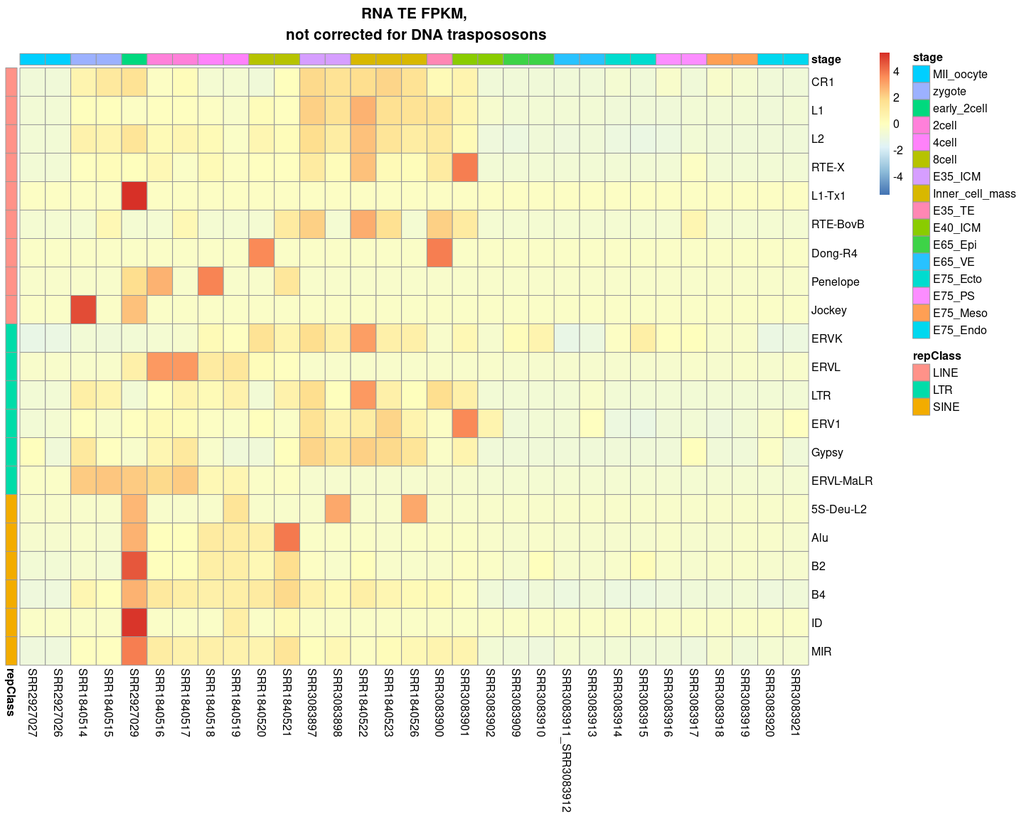

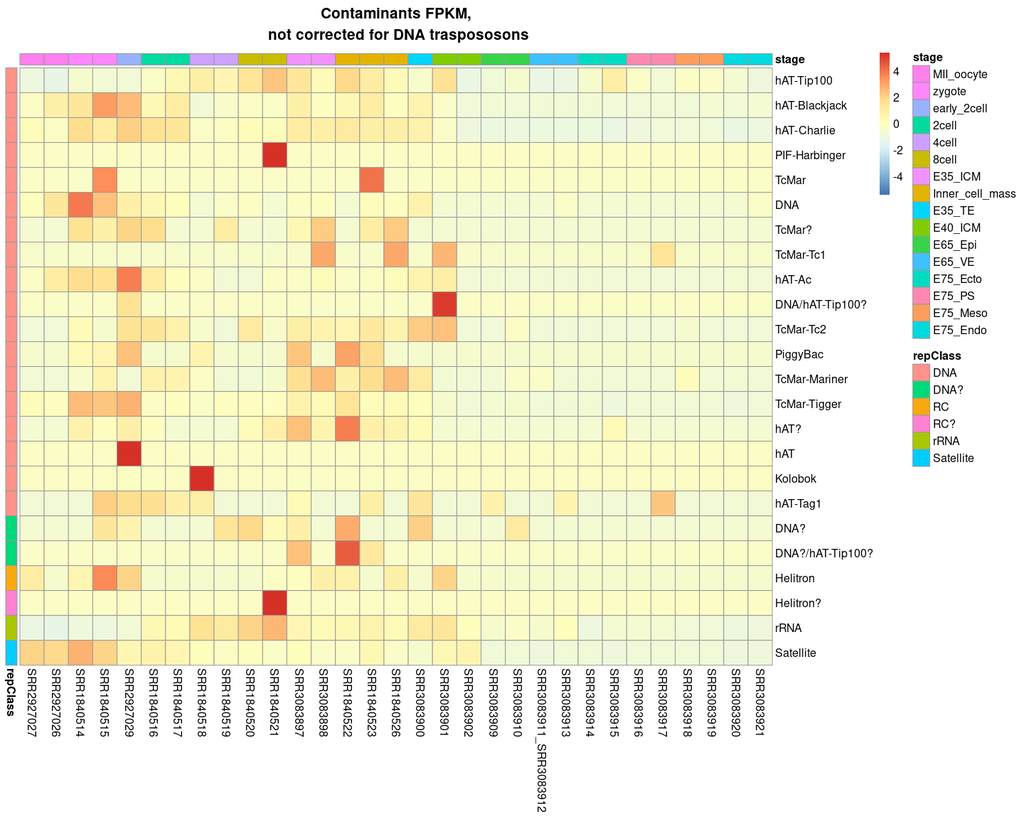

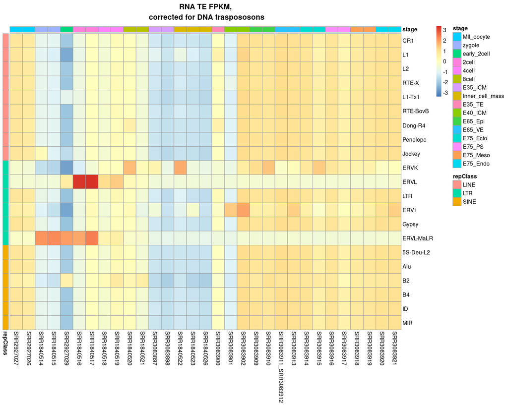

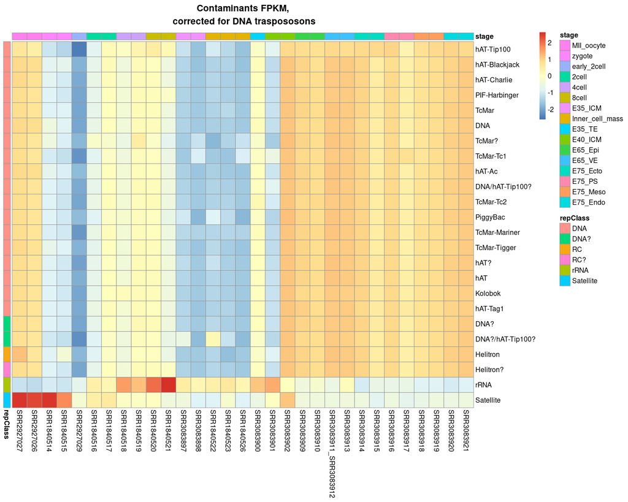

Note that when correcting for DNA FPKM preimplantation embryonic stages get penalized compared to the oocyte i.e. oocyte FPKM values are overestimated.

# 4 DE-Seq analysis of RNA transposons - preimplantation stages only

I include the **FPKM of DNA repetitive elements as confounding factors in DESeq2 formula**.

Before running the Differential Expression analysis, the data are pre-filtered to remove all repetitive elements with < 10 reads among all samples.

# 5 Results

I exclude the comparisons including the preEGA 2c stage because, after filtering bad samples, this stage includes only one biological replicate.

zygote vs MII oocyte

|  | baseMean | log2FoldChange | lfcSE | pvalue | padj | repName |
| --- | --- | --- | --- | --- | --- | --- |
| MURVY-int | 17.489346 | 16.123318 | 2.3754315 | 0.0000000 | 0.0000000 | MURVY-int |
| L3 | 2.259528 | 25.100060 | 3.9912114 | 0.0000000 | 0.0000000 | L3 |
| MLT1H2 | 1.929309 | 24.450194 | 4.0643392 | 0.0000000 | 0.0000000 | MLT1H2 |
| L1M3c | 2.014150 | 23.953139 | 4.0047707 | 0.0000000 | 0.0000000 | L1M3c |
| ERVB4_1-I_MM | 10.728657 | 14.794992 | 2.3933924 | 0.0000000 | 0.0000000 | ERVB4_1-I_MM |
| L1MB1 | 8.944834 | 15.333334 | 2.5380063 | 0.0000000 | 0.0000000 | L1MB1 |
| B1_Mur2 | 5.087119 | -17.141324 | 3.1781336 | 0.0000000 | 0.0000005 | B1_Mur2 |
| ORR1F-int | 3.390474 | 17.394624 | 3.4001101 | 0.0000000 | 0.0000019 | ORR1F-int |
| MIRb | 9.315072 | 11.801223 | 2.2916661 | 0.0000000 | 0.0000022 | MIRb |
| L1MdTf_III | 467.098252 | 8.152292 | 1.5973478 | 0.0000001 | 0.0000042 | L1MdTf_III |
| B1_Mm | 54.680162 | 10.677987 | 2.1816098 | 0.0000001 | 0.0000075 | B1_Mm |
| L1MdF_III | 355.903798 | 4.844318 | 0.9502548 | 0.0000002 | 0.0000085 | L1MdF_III |
| MLTR31F_MM | 5.592705 | 13.162153 | 2.8219144 | 0.0000003 | 0.0000157 | MLTR31F_MM |
| L1Lx_I | 248.597975 | 4.284701 | 0.8716753 | 0.0000005 | 0.0000192 | L1Lx_I |
| L1MdA_VII | 177.990790 | 7.818331 | 1.6533611 | 0.0000005 | 0.0000192 | L1MdA_VII |
| L1MdA_II | 508.081704 | 7.799417 | 1.6499959 | 0.0000005 | 0.0000192 | L1MdA_II |
| RLTR11C_MM | 6.211872 | 11.416535 | 2.6108976 | 0.0000014 | 0.0000482 | RLTR11C_MM |
| L1MdA_IV | 118.268209 | 7.322466 | 1.6190999 | 0.0000014 | 0.0000482 | L1MdA_IV |
| L1MdFanc_II | 224.658304 | 7.364849 | 1.6347466 | 0.0000015 | 0.0000482 | L1MdFanc_II |
| L1MdF_IV | 288.023397 | 4.823692 | 1.0382081 | 0.0000015 | 0.0000482 | L1MdF_IV |
| RMER16B2 | 7.923775 | 12.385020 | 2.9011649 | 0.0000020 | 0.0000601 | RMER16B2 |
| MLT1J2 | 1.077170 | 21.566031 | 5.5758061 | 0.0000021 | 0.0000617 | MLT1J2 |
| RLTR47 | 1.071138 | 20.630234 | 5.4317648 | 0.0000033 | 0.0000916 | RLTR47 |
| L1MdF_V | 302.114976 | 4.742032 | 1.0748236 | 0.0000043 | 0.0001142 | L1MdF_V |
| L1MdTf_I | 877.178348 | 6.970023 | 1.6477903 | 0.0000054 | 0.0001362 | L1MdTf_I |
| MuLV-int | 97.372913 | -4.082503 | 0.9359080 | 0.0000060 | 0.0001468 | MuLV-int |
| L1MdV_II | 122.222081 | 7.727711 | 1.8634151 | 0.0000063 | 0.0001468 | L1MdV_II |
| L1MdV_III | 222.173263 | 3.361167 | 0.7683030 | 0.0000065 | 0.0001468 | L1MdV_III |
| L1MdF_I | 222.429140 | 4.552583 | 1.0899922 | 0.0000112 | 0.0002445 | L1MdF_I |
| L1MdMus_II | 153.746708 | 6.385530 | 1.6517153 | 0.0000224 | 0.0004750 | L1MdMus_II |

[output cut: 51 more lines]

postEGA 2c vs zygote

|  | baseMean | log2FoldChange | lfcSE | pvalue | padj | repName |
| --- | --- | --- | --- | --- | --- | --- |
| B1_Mur3 | 8.577082e+00 | 40.5745390 | 1.7668243 | 0.0000000 | 0.0000000 | B1_Mur3 |
| IAPLTR4_I | 4.665418e+00 | 41.0475153 | 2.2915965 | 0.0000000 | 0.0000000 | IAPLTR4_I |
| L1ME3F | 1.524686e+00 | 41.7591557 | 2.5142810 | 0.0000000 | 0.0000000 | L1ME3F |
| B1F2 | 2.078005e+00 | 39.2771825 | 2.3880701 | 0.0000000 | 0.0000000 | B1F2 |
| RLTR17C_Mm | 1.350501e+00 | 41.0583592 | 2.6930792 | 0.0000000 | 0.0000000 | RLTR17C_Mm |
| ORR1A1-int | 2.406783e+03 | 4.7116508 | 0.3476738 | 0.0000000 | 0.0000000 | ORR1A1-int |
| MT2_Mm | 3.435584e+03 | 7.8368108 | 0.5666464 | 0.0000000 | 0.0000000 | MT2_Mm |
| ORR1A0 | 2.771575e+02 | 6.4116945 | 0.5177474 | 0.0000000 | 0.0000000 | ORR1A0 |
| RLTR20B4_MM | 1.098372e+00 | 38.0465582 | 3.1320544 | 0.0000000 | 0.0000000 | RLTR20B4_MM |
| MER89 | 1.789222e+02 | 6.6234855 | 0.5906023 | 0.0000000 | 0.0000000 | MER89 |
| ORR1A0-int | 4.219488e+03 | 6.9294846 | 0.6272349 | 0.0000000 | 0.0000000 | ORR1A0-int |
| ERVB3_1-LTR_MM | 8.328430e-01 | 35.6805956 | 3.1186359 | 0.0000000 | 0.0000000 | ERVB3_1-LTR_MM |
| IAPA_MM-int | 1.000090e+00 | 36.8210933 | 3.2993894 | 0.0000000 | 0.0000000 | IAPA_MM-int |
| ORR1A1 | 2.110629e+02 | 4.3175670 | 0.4067613 | 0.0000000 | 0.0000000 | ORR1A1 |
| MER67C | 8.659550e-01 | -38.0592469 | 3.4611363 | 0.0000000 | 0.0000000 | MER67C |
| MERVL_2A-int | 4.766561e+02 | 4.1723171 | 0.4511531 | 0.0000000 | 0.0000000 | MERVL_2A-int |
| B1_Mur2 | 5.087119e+00 | 18.1564150 | 1.9185747 | 0.0000000 | 0.0000000 | B1_Mur2 |
| MERVL-int | 2.619264e+04 | 6.8041457 | 0.7970482 | 0.0000000 | 0.0000000 | MERVL-int |
| RLTR19 | 7.734642e+01 | 3.8984167 | 0.4521126 | 0.0000000 | 0.0000000 | RLTR19 |
| MMETn-int | 2.061007e+03 | 3.6736942 | 0.4571004 | 0.0000000 | 0.0000000 | MMETn-int |
| RLTR10C | 1.179327e+02 | 3.3993346 | 0.4435429 | 0.0000000 | 0.0000000 | RLTR10C |
| MT2C_Mm | 8.727671e+01 | 3.4739326 | 0.4763378 | 0.0000000 | 0.0000000 | MT2C_Mm |
| ORR1A2-int | 1.107221e+03 | 2.3020798 | 0.3056407 | 0.0000000 | 0.0000000 | ORR1A2-int |
| MLTR32C_MM | 9.280155e-01 | -27.3842169 | 3.7445579 | 0.0000000 | 0.0000000 | MLTR32C_MM |
| ORR1A4-int | 2.911690e+02 | 2.6115237 | 0.3756519 | 0.0000000 | 0.0000000 | ORR1A4-int |
| ERVB4_2-LTR_MM | 9.324328e+01 | 3.8981474 | 0.5955660 | 0.0000000 | 0.0000000 | ERVB4_2-LTR_MM |
| MLT2E | 5.228375e-01 | 29.4690271 | 4.2341893 | 0.0000000 | 0.0000000 | MLT2E |
| LTR82A | 1.500173e+00 | -20.3064501 | 2.9683728 | 0.0000000 | 0.0000000 | LTR82A |
| MT2B2 | 8.224243e+01 | 2.6529847 | 0.3982994 | 0.0000000 | 0.0000000 | MT2B2 |
| HERV16-int | 6.475189e-01 | -27.6231935 | 4.0961022 | 0.0000000 | 0.0000000 | HERV16-int |

[output cut: 113 more lines]

fourCell vs postEGA 2c

|  | baseMean | log2FoldChange | lfcSE | pvalue | padj | repName |
| --- | --- | --- | --- | --- | --- | --- |
| MER74A | 1.154549e+00 | -41.8873239 | 2.3062932 | 0.0000000 | 0.0000000 | MER74A |
| LTR16A | 1.244804e+00 | -40.6477667 | 2.2486302 | 0.0000000 | 0.0000000 | LTR16A |
| L1ME3G | 1.601564e+00 | -40.6807437 | 2.2950113 | 0.0000000 | 0.0000000 | L1ME3G |
| LTR16 | 1.060134e+00 | -41.7260918 | 2.4670821 | 0.0000000 | 0.0000000 | LTR16 |
| BGLII_B2 | 8.771991e-01 | -37.7726313 | 2.5833329 | 0.0000000 | 0.0000000 | BGLII_B2 |
| RMER16B | 7.956487e-01 | -46.3582868 | 3.2419333 | 0.0000000 | 0.0000000 | RMER16B |
| RLTR20B3A_MM | 1.821642e+00 | -31.3707312 | 2.4263572 | 0.0000000 | 0.0000000 | RLTR20B3A_MM |
| MER67C | 8.659550e-01 | 37.5730657 | 2.9734835 | 0.0000000 | 0.0000000 | MER67C |
| L1MEi | 3.980023e-01 | -44.1352237 | 3.8123047 | 0.0000000 | 0.0000000 | L1MEi |
| HAL1b | 4.078826e+00 | -21.6669414 | 1.8663990 | 0.0000000 | 0.0000000 | HAL1b |
| MER31A | 7.368878e-01 | -29.7119312 | 2.6043561 | 0.0000000 | 0.0000000 | MER31A |
| HAL1ME | 4.859426e-01 | -41.6562418 | 3.7718629 | 0.0000000 | 0.0000000 | HAL1ME |
| BGLII_Mus | 4.071061e+00 | -18.2051978 | 1.7289669 | 0.0000000 | 0.0000000 | BGLII_Mus |
| LTR16E1 | 1.188892e+00 | -28.5080887 | 2.8075928 | 0.0000000 | 0.0000000 | LTR16E1 |
| MLT1E3 | 6.394781e+00 | -17.0381273 | 1.7135041 | 0.0000000 | 0.0000000 | MLT1E3 |
| RLTR45-int | 6.890537e+03 | 3.7783976 | 0.4560376 | 0.0000000 | 0.0000000 | RLTR45-int |
| MER70A | 1.188020e+01 | -15.6879304 | 1.7727084 | 0.0000000 | 0.0000000 | MER70A |
| L1M1 | 5.591567e-01 | 26.6469438 | 3.0836981 | 0.0000000 | 0.0000000 | L1M1 |
| RLTR20A4 | 5.853406e+00 | -16.5275480 | 1.9311413 | 0.0000000 | 0.0000000 | RLTR20A4 |
| MER34A1 | 5.869046e-01 | -24.4368005 | 2.9962731 | 0.0000000 | 0.0000000 | MER34A1 |
| ERVB4_2-I_MM | 7.990747e+02 | 3.9499700 | 0.5413645 | 0.0000000 | 0.0000000 | ERVB4_2-I_MM |
| MLTR32C_MM | 9.280155e-01 | 25.7056502 | 3.2521799 | 0.0000000 | 0.0000000 | MLTR32C_MM |
| LTR67B | 1.612421e+00 | 18.3613365 | 2.3786218 | 0.0000000 | 0.0000000 | LTR67B |
| PB1D10 | 1.808123e+00 | -22.3650510 | 3.3091513 | 0.0000000 | 0.0000000 | PB1D10 |
| RLTR20A2 | 1.205165e+00 | -15.4078342 | 2.3100160 | 0.0000000 | 0.0000000 | RLTR20A2 |
| RLTR13B1 | 1.188613e+02 | 2.9993036 | 0.6666245 | 0.0000000 | 0.0000000 | RLTR13B1 |
| MLTR31E_MM | 6.072398e-01 | -23.3286670 | 3.8748771 | 0.0000000 | 0.0000000 | MLTR31E_MM |
| MMETn-int | 2.061007e+03 | 1.7062072 | 0.3502718 | 0.0000000 | 0.0000004 | MMETn-int |
| L1M2c | 1.221708e+00 | -15.5185875 | 2.7993336 | 0.0000000 | 0.0000005 | L1M2c |
| RLTR40 | 2.656145e+02 | -2.2747420 | 0.5522913 | 0.0000000 | 0.0000005 | RLTR40 |

[output cut: 52 more lines]

|  | baseMean | log2FoldChange | lfcSE | pvalue | padj | repName |
| --- | --- | --- | --- | --- | --- | --- |
| MER74A | 1.154549e+00 | 42.9370568 | 2.2153706 | 0.0000000 | 0.0000000 | MER74A |
| LTR16 | 1.060134e+00 | 43.0355809 | 2.3049606 | 0.0000000 | 0.0000000 | LTR16 |
| LTR16A | 1.244804e+00 | 40.1705417 | 2.2783389 | 0.0000000 | 0.0000000 | LTR16A |
| L1ME3G | 1.601564e+00 | 39.7291938 | 2.4039030 | 0.0000000 | 0.0000000 | L1ME3G |
| BGLII_B2 | 8.771991e-01 | 38.6169652 | 2.4785823 | 0.0000000 | 0.0000000 | BGLII_B2 |
| MLT2B5 | 8.732039e-01 | -39.7751446 | 2.6111398 | 0.0000000 | 0.0000000 | MLT2B5 |
| MTE2a-int | 4.230256e+00 | -29.8376157 | 2.0228631 | 0.0000000 | 0.0000000 | MTE2a-int |
| RMER16B | 7.956487e-01 | 46.5258269 | 3.1623358 | 0.0000000 | 0.0000000 | RMER16B |
| RLTR20B3A_MM | 1.821642e+00 | 32.0446837 | 2.3388095 | 0.0000000 | 0.0000000 | RLTR20B3A_MM |
| HAL1ME | 4.859426e-01 | 43.6946566 | 3.4892168 | 0.0000000 | 0.0000000 | HAL1ME |
| ERVB5_1-LTR_MM | 8.427935e-01 | -37.4695955 | 3.0509452 | 0.0000000 | 0.0000000 | ERVB5_1-LTR_MM |
| L1MEi | 3.980023e-01 | 44.2026141 | 3.7581379 | 0.0000000 | 0.0000000 | L1MEi |
| LTR16E1 | 1.188892e+00 | 30.3574494 | 2.6110368 | 0.0000000 | 0.0000000 | LTR16E1 |
| LTR73 | 5.699419e-01 | -38.5342101 | 3.3272057 | 0.0000000 | 0.0000000 | LTR73 |
| MER31A | 7.368878e-01 | 29.0634190 | 2.6324489 | 0.0000000 | 0.0000000 | MER31A |
| MER67D | 6.451151e-01 | -33.3663197 | 3.1355030 | 0.0000000 | 0.0000000 | MER67D |
| MLT1E3 | 6.394781e+00 | 16.9550514 | 1.7139378 | 0.0000000 | 0.0000000 | MLT1E3 |
| MLT2B2 | 9.607440e+00 | -17.2617616 | 1.7641358 | 0.0000000 | 0.0000000 | MLT2B2 |
| L1M1 | 5.591567e-01 | -26.6025540 | 2.9762394 | 0.0000000 | 0.0000000 | L1M1 |
| PB1D10 | 1.808123e+00 | 25.9135435 | 2.9594673 | 0.0000000 | 0.0000000 | PB1D10 |
| MLT1G1-int | 1.069853e+00 | -25.5082574 | 2.9772912 | 0.0000000 | 0.0000000 | MLT1G1-int |
| BGLII_Mus | 4.071061e+00 | 15.9362647 | 1.8761991 | 0.0000000 | 0.0000000 | BGLII_Mus |
| RLTR20A2 | 1.205165e+00 | 16.7299668 | 2.1536213 | 0.0000000 | 0.0000000 | RLTR20A2 |
| MER70A | 1.188020e+01 | 14.5011206 | 1.9062732 | 0.0000000 | 0.0000000 | MER70A |
| MER34A1 | 5.869046e-01 | 22.9829654 | 3.0937415 | 0.0000000 | 0.0000000 | MER34A1 |
| MTA_Mm-int | 6.087378e+04 | -1.7980604 | 0.2687871 | 0.0000000 | 0.0000000 | MTA_Mm-int |
| HERV16-int | 6.475189e-01 | 23.1533861 | 3.2771092 | 0.0000000 | 0.0000000 | HERV16-int |
| L1M2a | 1.614397e+00 | 14.9680746 | 2.2665243 | 0.0000000 | 0.0000000 | L1M2a |
| RLTR20A4 | 5.853406e+00 | 14.1424080 | 2.1623793 | 0.0000000 | 0.0000000 | RLTR20A4 |
| MT-int | 1.403151e+03 | -1.6219219 | 0.2950008 | 0.0000000 | 0.0000000 | MT-int |
| LTR82A | 1.500173e+00 | 14.0188072 | 2.4992610 | 0.0000000 | 0.0000004 | LTR82A |
| ORR1A2-int | 1.107221e+03 | -1.2015119 | 0.2296551 | 0.0000000 | 0.0000005 | ORR1A2-int |
| ORR1A1-int | 2.406783e+03 | -1.2417236 | 0.2473382 | 0.0000001 | 0.0000013 | ORR1A1-int |
| MERVL_2A-int | 4.766561e+02 | -1.5516745 | 0.3234327 | 0.0000001 | 0.0000013 | MERVL_2A-int |
| PB1 | 5.533446e-01 | -22.6431759 | 4.2798378 | 0.0000001 | 0.0000017 | PB1 |
| LTR16A2 | 7.645437e-01 | 14.8893356 | 2.9330508 | 0.0000003 | 0.0000049 | LTR16A2 |
| MTB-int | 1.691696e+02 | -1.4109264 | 0.3077581 | 0.0000003 | 0.0000058 | MTB-int |
| LTR33A | 4.380321e-01 | 23.6535046 | 4.7761729 | 0.0000005 | 0.0000080 | LTR33A |
| LTR106_Mam | 4.014965e-01 | 22.9140231 | 4.8521481 | 0.0000013 | 0.0000205 | LTR106_Mam |
| ERVL-B4-int | 6.597013e+01 | -1.3906709 | 0.3753930 | 0.0000105 | 0.0001673 | ERVL-B4-int |
| MT2_Mm | 3.435584e+03 | -1.4467194 | 0.4039376 | 0.0000128 | 0.0001985 | MT2_Mm |
| ORR1A0-int | 4.219488e+03 | -1.4383667 | 0.4466146 | 0.0000347 | 0.0005256 | ORR1A0-int |
| MTA_Mm | 4.392673e+03 | -1.2317610 | 0.3599394 | 0.0000358 | 0.0005293 | MTA_Mm |
| MERVL-int | 2.619264e+04 | -1.4335223 | 0.5826347 | 0.0001667 | 0.0023821 | MERVL-int |
| ORR1A1 | 2.110629e+02 | -0.8932291 | 0.3002733 | 0.0001685 | 0.0023821 | ORR1A1 |
| ETnERV2-int | 1.841801e+02 | 1.0188875 | 0.3589394 | 0.0002076 | 0.0028709 | ETnERV2-int |
| RLTR19 | 7.734642e+01 | -0.8928627 | 0.3460393 | 0.0004125 | 0.0055813 | RLTR19 |
| RLTR45 | 1.495378e+02 | 1.0590291 | 0.4287146 | 0.0004222 | 0.0055935 | RLTR45 |
| ORR1A0 | 2.771575e+02 | -0.8483418 | 0.3609497 | 0.0006982 | 0.0090625 | ORR1A0 |
| RLTR13B1 | 1.188613e+02 | 1.0015425 | 0.5224619 | 0.0012988 | 0.0165205 | RLTR13B1 |
| IAPEy-int | 3.339986e+01 | -0.9166719 | 0.5200824 | 0.0020229 | 0.0252272 | IAPEy-int |
| RodERV21-int | 4.415386e+01 | 0.7390137 | 0.4238362 | 0.0027873 | 0.0340903 | RodERV21-int |
| RLTR13D5 | 2.102158e+01 | 0.9635688 | 0.7274406 | 0.0031076 | 0.0372913 | RLTR13D5 |
| MTE2b-int | 1.536049e+01 | -0.8625013 | 0.8366574 | 0.0049520 | 0.0583239 | MTE2b-int |
| MTB_Mm-int | 2.022200e+02 | -0.7295087 | 0.5687191 | 0.0069076 | 0.0798764 | MTB_Mm-int |
| MMERVK9C_I-int | 2.056512e+02 | 0.6076116 | 0.4409928 | 0.0073277 | 0.0829456 | MMERVK9C_I-int |
| ERVB4_2-I_MM | 7.990747e+02 | 0.6823698 | 0.5224618 | 0.0074338 | 0.0829456 | ERVB4_2-I_MM |
| MMERVK10D3_I-int | 8.657964e+01 | -0.5797988 | 0.4237935 | 0.0077873 | 0.0853915 | MMERVK10D3_I-int |
| L1MdA_V | 5.836978e+01 | 0.6120374 | 0.4783734 | 0.0090282 | 0.0973213 | L1MdA_V |
| MER21C | 1.626781e+01 | -0.6868459 | 0.5910802 | 0.0092865 | 0.0984371 | MER21C |
| L1VL1 | 1.790925e+01 | 0.6985022 | 0.6296550 | 0.0094927 | 0.0989731 | L1VL1 |

## 5.1 MA-plots

In the MA-plots:

- The threshold used for a dot to be coloured based on repFamily is p-value adjusted < 0.1.
- Transposable elements whose mean expression > 10 and log2FoldChange > 0.2 (or < -0.2) are labeled (but labeling is limited by max.overlap parameter).

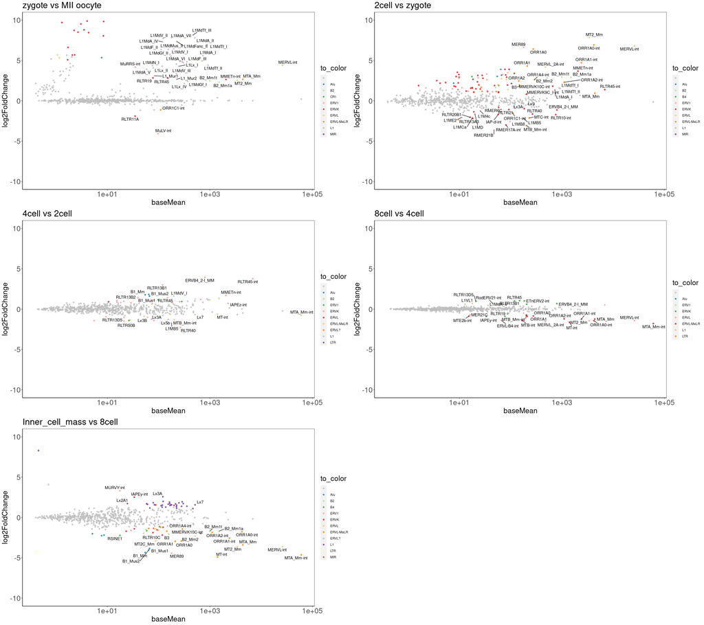